# R Tutorial: Summarizing relationships between two quantitative variables

# Learning Objectives:

- Create a scatterplot
- Compute the correlation coefficient
- Estimate the regression equation (least-squares line)
- Create residual diagnostic plots for linear regression

# Example data

Read the “coffee.csv” file containing survey responses from 65 students about coffee consumption.

```r
coffee <- read.csv("coffee.csv")
```

Let’s examine the association between the quantitative variables `age` (the age in years of respondents) and `dollarsCoffee` (the amount of money respondents spend on coffee per week). First, we will exclude missing values from the data frame using the `na.omit()` function. The new data frame will have 61 complete observations.

```r
coffee <- na.omit(coffee)
```

##### TRY IT: Check that there are 61 observations in the coffee data frame

```r
str(coffee)   ## 61 observations
nrow(coffee)  ## 61 rows
```

# 1 Scatterplot

The function to create a scatterplot is: `plot(x, y, main, xlab, ylab, col, pch, ...)`

- **x**: numeric vector to appear on x-axis
- **y**: numeric vector to appear on y-axis
- **main** (optional): title for plot
- **xlab** (optional): title for x-axis (horizontal axis)
- **ylab** (optional): title for y-axis (vertical axis)
- **col** (optional): colour of the points
- **pch** (optional): integer from 0 to 25 representing the plotting symbol to use

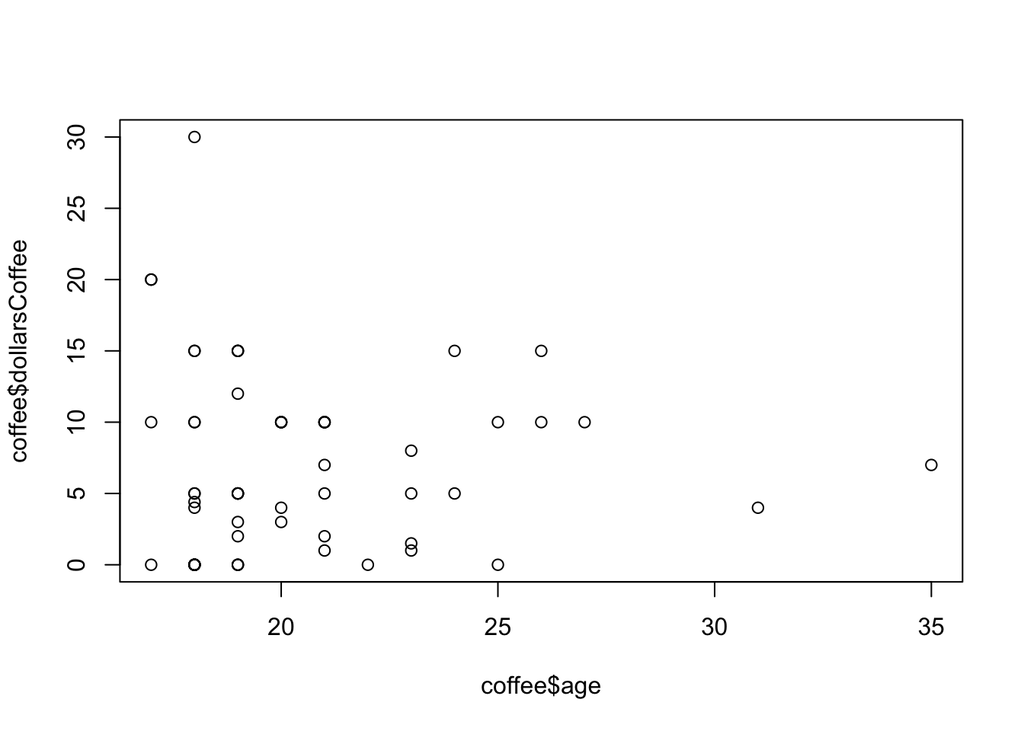

```r
plot(x = coffee$age, y = coffee$dollarsCoffee)
```

Let’s add a title, axis labels, and customize the plotting symbol and colour.

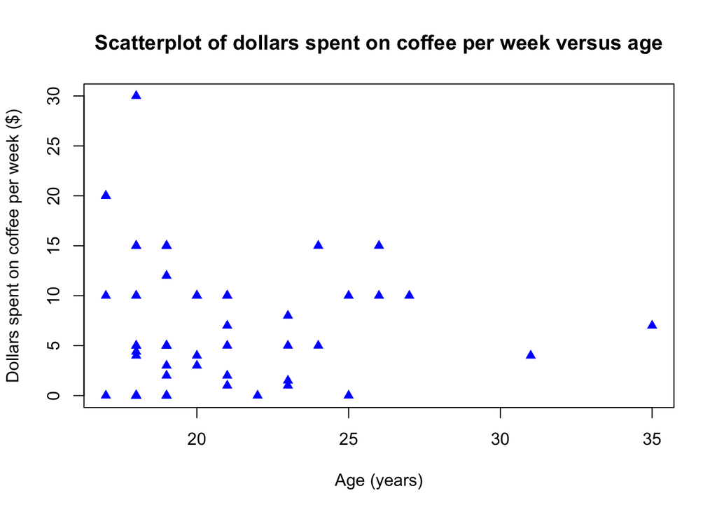

```r
plot(coffee$age, coffee$dollarsCoffee,
     main = "Scatterplot of dollars spent on coffee per week versus age",
     xlab = "Age (years)", ylab = "Dollars spent on coffee per week ($)",
     col = "blue", pch = 17)
```

We can also customize the axis limits (`xlim` or `ylim`):

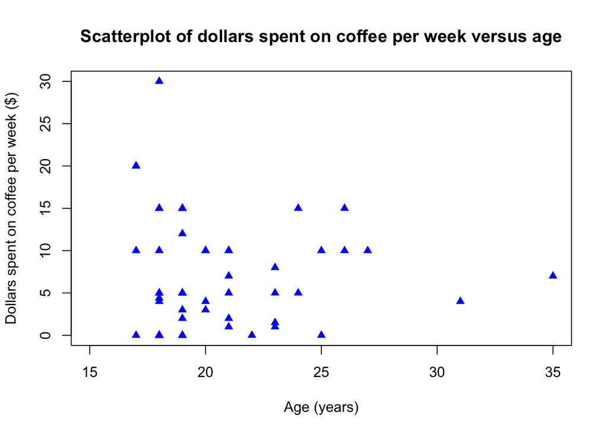

```r
plot(coffee$age, coffee$dollarsCoffee,
     main = "Scatterplot of dollars spent on coffee per week versus age",
     xlab = "Age (years)", ylab = "Dollars spent on coffee per week ($)",
     col = "blue", pch = 17,
     xlim = c(15, 35))
```

# 2 Correlation coefficient

The function to compute the correlation coefficient (r) is: `cor(x, y, ...)`

- **x**: numeric vector
- **y**: numeric vector

```r
cor(x = coffee$age, y = coffee$dollarsCoffee)
```

```
## [1] -0.01784347
```

From the output, $r = -0.01784347$.

# 3 Linear regression

## 3.1 Least-squares line

The function to estimate the equation of the least-squares regression line is: `lm(formula, data, ...)`

- **formula**: `y ~ x`, where `y` is the response variable and `x` is the explantory variable
- **data** (optional): data frame containing the variabls `x` and `y`

```r
# We can list the variables by extracting them from the data frame
lm(formula = coffee$dollarsCoffee ~ coffee$age)

# Or we can use the variable names, and tell the function which data frame to find them in
lm(formula = dollarsCoffee ~ age, data = coffee)
```

```
##
## Call:
## lm(formula = dollarsCoffee ~ age, data = coffee)
##
## Coefficients:
## (Intercept)          age
##     7.62055     -0.03282
```

The equation of the least-squares line is:

- **$\hat{ y } = 7.62055 - 0.03282x$**

We can extract more information about this regression model using the `summary()` function.

```r
# First we save our regresson model as an object named "model"
model <- lm(dollarsCoffee ~ age, coffee)
summary(model)
```

```
##
## Call:
## lm(formula = dollarsCoffee ~ age, data = coffee)
##
## Residuals:
##    Min     1Q Median     3Q    Max
## -7.063 -5.366 -1.931  3.069 22.970
##
## Coefficients:
##             Estimate Std. Error t value Pr(>|t|)
## (Intercept)  7.62055    4.96404   1.535    0.130
## age         -0.03282    0.23939  -0.137    0.891
##
## Residual standard error: 6.321 on 59 degrees of freedom
## Multiple R-squared:  0.0003184,  Adjusted R-squared:  -0.01663
## F-statistic: 0.01879 on 1 and 59 DF,  p-value: 0.8914
```

From this output, we see that

- RMSE = 6.321 (called `Residual standard error`)
- R-squared = 0.0003184 (called `Multiple R-squared`)

Note that the R-squared value above is expressed as proportion between 0 and 1. Multiply this value by 100 to compute the percentage ($R^2 = 0.03\%$).

## 3.2 Diagnostic plots

We can use the function `residuals()` to get the residuals from our regression model object.

```r
residuals(model)
```

```
##           1           2           3           4           5           6
##  2.93731129 -4.99705827  8.00294173  3.03575695  3.23264826 -1.86579739
##           7           8           9          10          11          12
## -2.60327564 -3.99705827  3.03575695 -5.36579739 -6.99705827  5.00294173
##          13          14          15          16          17          18
## -1.99705827  3.03575695 -5.93142783  7.97012651  8.23264826  0.52798523
##          20          21          22          23          24          26
## -6.99705827 22.97012651  8.00294173  0.06857217 -2.02987349 -1.93142783
##          27          28          29          30          31          32
## -7.02987349 -1.99705827 -2.96424305 -7.02987349 -7.06268871  3.19983304
##          33          34          35          36          37          38
##  3.26546348 -3.96424305 -2.62987349  3.06857217  1.13420261  8.00294173
##          39          40          41          42          43          44
## -6.99705827  8.16701782  3.03575695  2.97012651 -1.83298218 -7.02987349
##          45          46          48          49          50          51
## -7.02987349 -7.02987349 -4.93142783 -7.02987349 12.93731129 12.93731129
##          52          53          54          55          56          57
##  7.97012651 -6.89861261 -5.86579739 -1.99705827 -3.02987349  3.06857217
##          58          59          60          61          62          63
## -1.99705827 -2.02987349  2.97012651 -7.02987349 -6.80016696  3.06857217
##          64
##  3.06857217
```

### 3.2.1 Residual plot

We can use the `plot()` function to create a scatterplot of the residuals versus the explanatory variable (age).

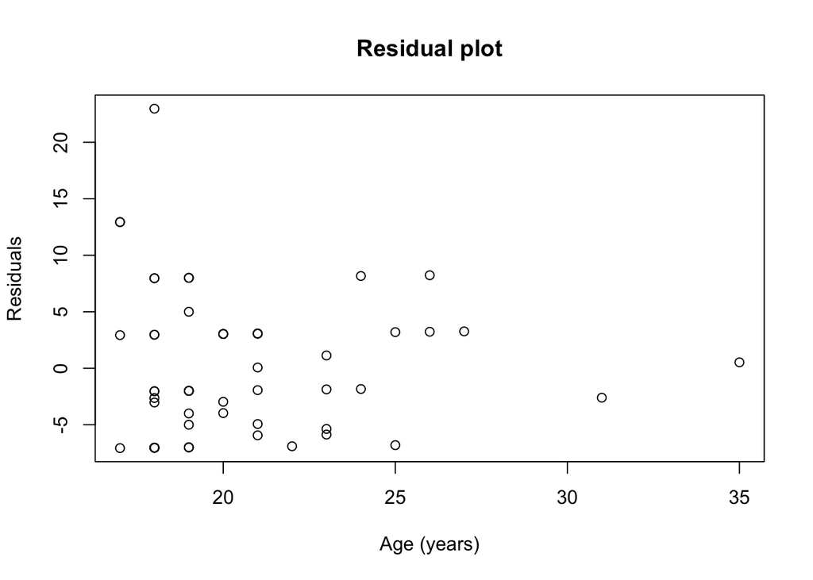

```r
plot(x = coffee$age,
     y = residuals(model),
     xlab = "Age (years)",
     ylab = "Residuals",
     main = "Residual plot")
```

We can use the `abline()` function to add a dashed horizontal line at residual = 0 to help assess patterns on the plot.

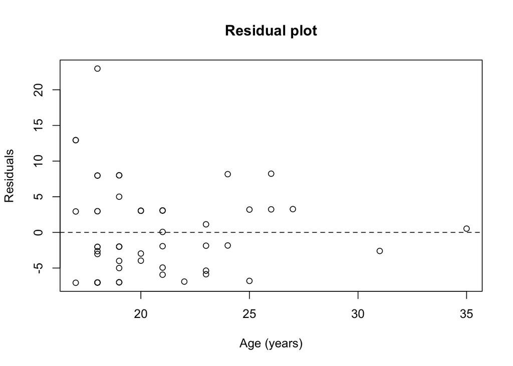

```r
# first draw the residual scatterplot
plot(x = coffee$age,
     y = residuals(model),
     xlab = "Age (years)",
     ylab = "Residuals",
     main = "Residual plot")

# then add the horizontal line (h) at 0 with a dashed line type (lty)
abline(h = 0, lty = "dashed")
```

### 3.2.2 Histogram of residuals

We will use the `hist()` function to create a histogram of the residuals.

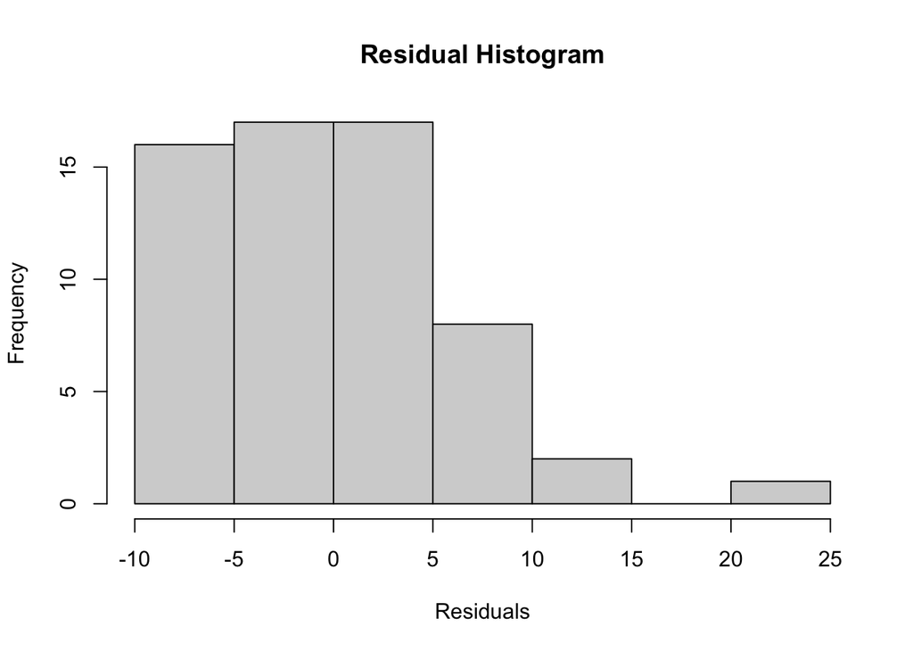

```r
hist(residuals(model),
     xlab = "Residuals",
     main = "Residual Histogram")
```

# Exercises

1. For the following questions, examine the relationship between `age` and `dollarsCoffee` for complete cases (respondents with no missing values) who live in Richmond. Start by creating a new data frame with these respondents only.
2. Create a scatterplot of `dollarsCoffee` versus `age`. Add a title and label the x and y axes.
3. Compute the correlation between `dollarsCoffee` and `age`.
4. Find the values of the slope and intercept for the least-squares regression line predicting `dollarsCoffee` from `age`.
5. Create another scatterplot of `dollarsCoffee` versus `age`, but this time add the least-squares regression line. (Hint: use `abline()`)
6. Create a residual scatterplot. Add a dashed horizontal line at residual = 0. (Hint: use `abline()`)
7. Create a histogram of residuals.
8. What happens to the regression line when you remove the 26-year-old respondent? Create another scatterplot without this respondent and draw the new regression line on the plot.

# Solutions

```r
# 1. Complete cases who live in Richmond
richmond <- coffee[coffee$city %in% "Richmond", ]
richmond <- na.omit(richmond)
str(richmond)
```

```
## 'data.frame':    16 obs. of  9 variables:
##  $ studentID    : int  2 3 8 15 17 20 34 36 38 39 ...
##  $ age          : int  19 19 19 21 26 19 20 21 19 19 ...
##  $ gender       : chr  "Female" "Female" "Female" "Male" ...
##  $ city         : chr  "Richmond" "Richmond" "Richmond" "Richmond" ...
##  $ drinkCoffee  : chr  "Yes" "Yes" "Yes" "Yes" ...
##  $ buyCoffee    : chr  "Once every two weeks" "1-2 times a week" "Once every two weeks" "Once every two weeks" ...
##  $ dollarsCoffee: num  2 15 3 1 15 0 3 10 15 0 ...
##  $ timeCoffee   : chr  "Afternoon" "Evening" "Afternoon" "Afternoon" ...
##  $ relyCoffee   : chr  "0" "7" "1" "2" ...
##  - attr(*, "na.action")= 'omit' Named int [1:4] 19 25 47 65
##   ..- attr(*, "names")= chr [1:4] "19" "25" "47" "65"
```

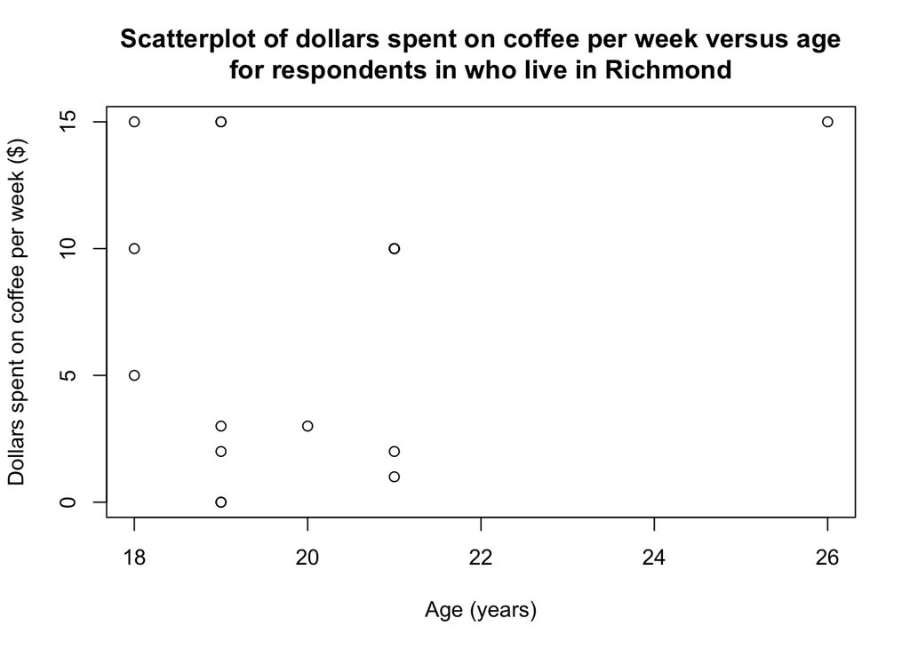

```r
# 2. Scatterplot
plot(x = richmond$age,
     y = richmond$dollarsCoffee,
     main = "Scatterplot of dollars spent on coffee per week versus age\nfor respondents in who live in Richmond",
     xlab = "Age (years)",
     ylab = "Dollars spent on coffee per week ($)")
```

```r
# 3. Correlation
cor(richmond$age, richmond$dollarsCoffee)
```

```
## [1] 0.2031201
```

```r
# 4. Regression line
line <- lm(dollarsCoffee ~ age, richmond)
summary(line)
```

```
##
## Call:
## lm(formula = dollarsCoffee ~ age, data = richmond)
##
## Residuals:
##     Min      1Q  Median      3Q     Max
## -6.8855 -4.9883  0.5117  3.9626  8.9088
##
## Coefficients:
##             Estimate Std. Error t value Pr(>|t|)
## (Intercept)  -4.6744    15.4339  -0.303    0.766
## age           0.5981     0.7706   0.776    0.451
##
## Residual standard error: 5.916 on 14 degrees of freedom
## Multiple R-squared:  0.04126,    Adjusted R-squared:  -0.02722
## F-statistic: 0.6025 on 1 and 14 DF,  p-value: 0.4506
```

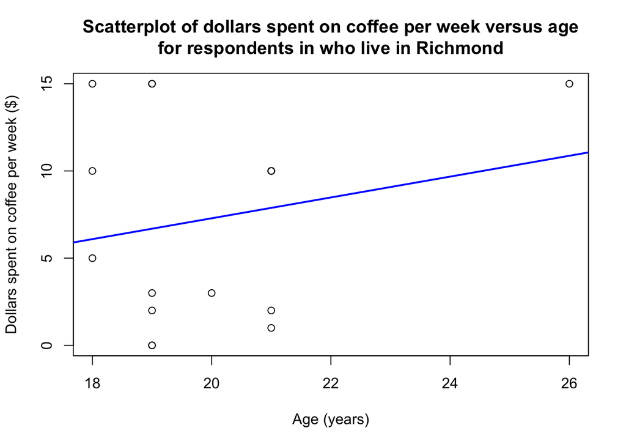

```r
# 5. Scatterplot with regression line
plot(x = richmond$age,
     y = richmond$dollarsCoffee,
     main = "Scatterplot of dollars spent on coffee per week versus age\nfor respondents in who live in Richmond",
     xlab = "Age (years)",
     ylab = "Dollars spent on coffee per week ($)")
abline(line, col = "blue", lwd = 2)
```

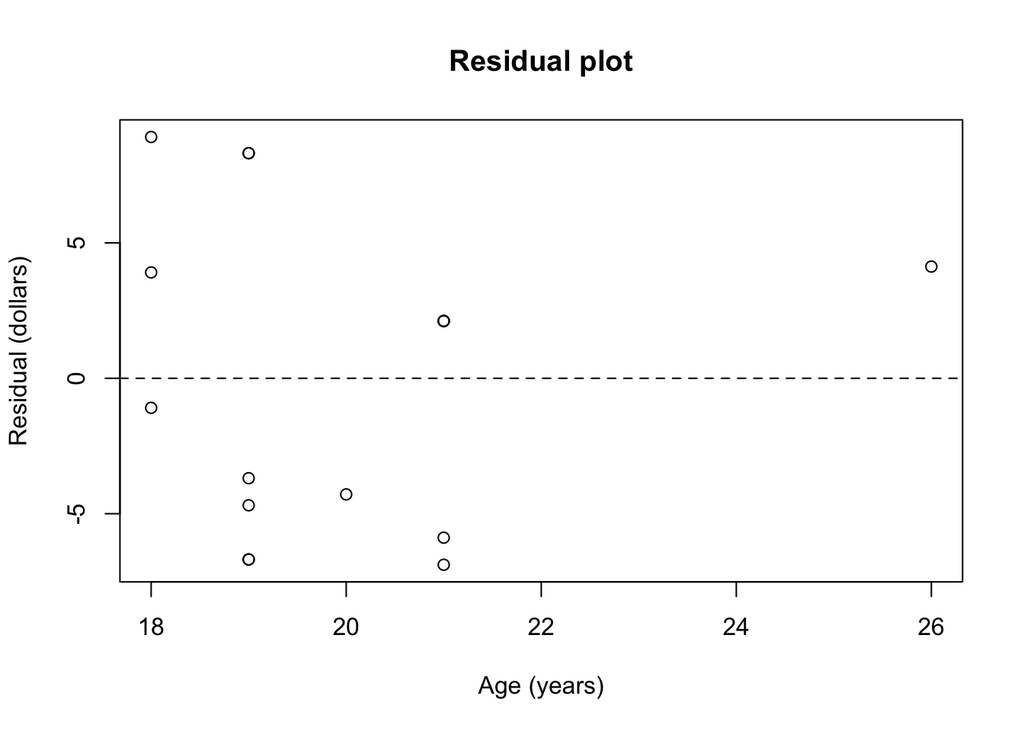

```r
# 6. Residual scatterplot
plot(x = richmond$age,
     y = residuals(line),
     main = "Residual plot",
     xlab = "Age (years)",
     ylab = "Residual (dollars)")
abline(h = 0, lty = "dashed")
```

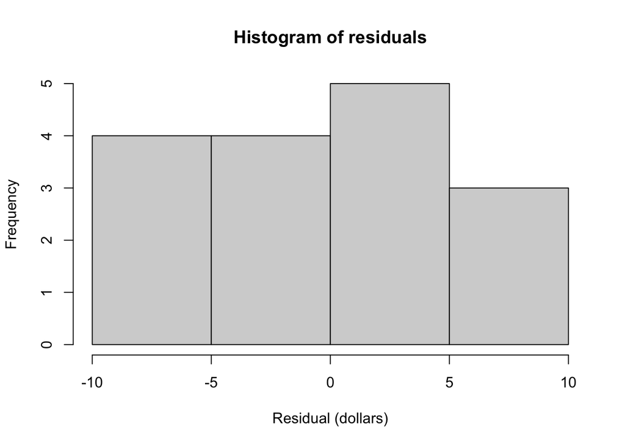

```r
# 7. Histogram of residuals
hist(residuals(line),
     main = "Histogram of residuals",
     xlab = "Residual (dollars)")
```

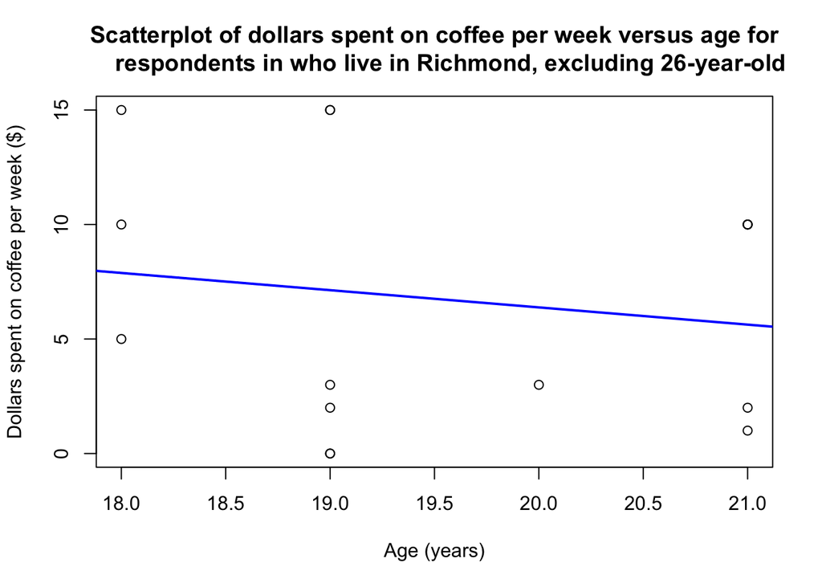

```r
# 8. Scatterplot with regression line excluding 26-year-old

# new data frame excluding 26-year-old
ex_26 <- richmond[richmond$age != 26, ]

# scatterplot
plot(x = ex_26$age,
     y = ex_26 $dollarsCoffee,
     main = "Scatterplot of dollars spent on coffee per week versus age for
     respondents in who live in Richmond, excluding 26-year-old",
     xlab = "Age (years)",
     ylab = "Dollars spent on coffee per week ($)")

# adding regression line
abline(lm(dollarsCoffee ~ age, ex_26), col = "blue", lwd = 2)
```